# Chromatin Loop Calling and Differential Analysis

Louis Meller

## Overview

This notebook reproduces the **chromatin loop calling and enhancer–promoter contact analysis** from Wang, R., Lee, J.-H., Kim, J. *et al.* “SARS-CoV-2 restructures host chromatin architecture.” *Nature Microbiology* **8**, 679–694 (2023). https://doi.org/10.1038/s41564-023-01344-8

Structural chromatin loops are formed primarily by cohesin-driven loop extrusion and anchored at convergent CTCF sites. The paper shows that SARS-CoV-2 infection preferentially depletes cohesin from intra-TAD regions, weakening these loops and reducing enhancer–promoter contacts at interferon response gene loci. We quantify and test these changes using a re-implementation of the HICCUPS loop-calling algorithm available in **cooltools**, followed by DESeq2 differential testing and Aggregate Peak Analysis (APA).

### Deviations from the paper

| Aspect | Paper | This analysis |
| --- | --- | --- |
| Chromosomes | Genome-wide | chr14 only |
| Resolutions | 5 kb + 10 kb | **10 kb only** — processed mcool files do not contain 5 kb bins |
| Loop merging | Full 4DN 5 kb + 10 kb strategy | Simplified to 10 kb union (single resolution) |

## 0. Data Preparation

Using the command line tool of cooler, we merged the replicates for Mock and SARS-CoV-2-infected conditions. In accordance with the original study’s methods, we processed the data at 10kb resolution. We then applied matrix balancing normalisation to correct for biase in the Hi-C reads. Lastly, we performed matrix coarsening to generate multi-resolution data.

We limited our analysis to chromosome 14 to reduce the computational complexity.

```bash
mkdir -p ./out

cooler merge ./out/merged_mock_HiC.mcool \
    ./GSE179184_RAW/mock_HiC_rep1.mcool::/resolutions/10000 \
    ./GSE179184_RAW/mock_HiC_rep2.mcool::/resolutions/10000

cooler merge ./out/merged_cov_HiC.mcool \
    ./GSE179184_RAW/cov_HiC_rep1.mcool::/resolutions/10000 \
    ./GSE179184_RAW/cov_HiC_rep2.mcool::/resolutions/10000

cooler balance ./out/merged_mock_HiC.mcool
cooler balance ./out/merged_cov_HiC.mcool

cooler zoomify -r 10000 \
    ./out/merged_mock_HiC.mcool \
    -o ./out/merged_mock_HiC_multi.mcool

cooler zoomify -r 10000 \
    ./out/merged_cov_HiC.mcool \
    -o ./out/merged_cov_HiC_multi.mcool
```

## 1. Loop Calling with `cooltools dots`

We use `cooltools dots` (the open2C re-implementation of HICCUPS (Rao *et al.*, 2014)) to detect pixels in the Hi-C contact matrix that are significantly enriched relative to a donut-shaped local expected background. Loop calling is performed on the merged replicate coolers to maximise read depth and sensitivity.

### 1.1 Compute Expected Values

`cooltools expected-cis` builds the background model of contact frequency as a function of genomic distance, required as input to `cooltools dots`.

```bash
# chr14 size in hg19 = 107,043,718 bp
echo -e "chr14\t0\t107043718\tchr14" > ./out/chr14_view.tsv

cooltools expected-cis \
    --nproc 4 \
    --view ./out/chr14_view.tsv \
    ./out/merged_mock_HiC_multi.mcool::/resolutions/10000 \
    -o ./out/expected_mock_10kb.tsv

cooltools expected-cis \
    --nproc 4 \
    --view ./out/chr14_view.tsv \
    ./out/merged_cov_HiC_multi.mcool::/resolutions/10000 \
    -o ./out/expected_cov_10kb.tsv
```

```
## INFO:root:creating a Pool of 4 workers
## INFO:root:creating a Pool of 4 workers
```

### 1.2 Call Loops at 10 kb Resolution

Dots are called using the parameters specified in **4DN benchmarking protocol** (Oksuz *et al.*, 2021, *Nat. Methods*)

```bash
cooltools dots \
    --nproc 4 \
    --view ./out/chr14_view.tsv \
    --fdr 0.1 \
    --clustering-radius 39000 \
    --max-loci-separation 10000000 \
    --tile-size 5000000 \
    --max-nans-tolerated 4 \
    ./out/merged_mock_HiC_multi.mcool::/resolutions/10000 \
    ./out/expected_mock_10kb.tsv \
    -o ./out/loops_mock_10kb.bedpe

cooltools dots \
    --nproc 4 \
    --view ./out/chr14_view.tsv \
    --fdr 0.1 \
    --clustering-radius 39000 \
    --max-loci-separation 10000000 \
    --tile-size 5000000 \
    --max-nans-tolerated 4 \
    ./out/merged_cov_HiC_multi.mcool::/resolutions/10000 \
    ./out/expected_cov_10kb.tsv \
    -o ./out/loops_cov_10kb.bedpe
```

```
## INFO:root:Using recommended donut-based kernels with w=5, p=2 for binsize=10000
## INFO:root:creating a Pool of 4 workers
## INFO:root:convolving 63 tiles to build histograms for lambda-bins
## INFO:root:Done building histograms in 3.031 sec ...
## INFO:root:Determined thresholds for every lambda-bin ...
## INFO:root:creating a Pool of 4 workers
## INFO:root:convolving 63 tiles to extract enriched pixels
## INFO:root:creating a Pool of 4 workers to tackle 63 tiles
## INFO:root:Done extracting enriched pixels in 2.736 sec ...
## INFO:root:Begin post-processing of 7770 filtered pixels
## INFO:root:preparing to extract needed q-values ...
## INFO:root:clustering enriched pixels in region: chr14
## INFO:root:detected 4925 clusters of 1.58+/-1.24 size
## INFO:root:Clustering is complete
## INFO:root:filtered 1788 out of 4925 centroids to reduce the number of false-positives
## INFO:root:Using recommended donut-based kernels with w=5, p=2 for binsize=10000
## INFO:root:creating a Pool of 4 workers
## INFO:root:convolving 63 tiles to build histograms for lambda-bins
## INFO:root:Done building histograms in 3.038 sec ...
## INFO:root:Determined thresholds for every lambda-bin ...
## INFO:root:creating a Pool of 4 workers
## INFO:root:convolving 63 tiles to extract enriched pixels
## INFO:root:creating a Pool of 4 workers to tackle 63 tiles
## INFO:root:Done extracting enriched pixels in 2.452 sec ...
## INFO:root:Begin post-processing of 7899 filtered pixels
## INFO:root:preparing to extract needed q-values ...
## INFO:root:clustering enriched pixels in region: chr14
## INFO:root:detected 5104 clusters of 1.55+/-1.06 size
## INFO:root:Clustering is complete
## INFO:root:filtered 1974 out of 5104 centroids to reduce the number of false-positives
```

## 2. Build a Consensus Loop Set

Find all loops that occurr in both conditions.

```r
read_loops <- function(path, tag) {
  raw <- read_tsv(path,
    comment = "#", col_types = cols(.default = "c"),
    show_col_types = FALSE
  )

  if (!("chrom1" %in% colnames(raw))) {
    colnames(raw)[1:6] <- c(
      "chrom1", "start1", "end1",
      "chrom2", "start2", "end2"
    )
  }

  raw %>%
    mutate(across(c(start1, end1, start2, end2), as.integer)) %>%
    filter(chrom1 == "chr14", chrom2 == "chr14") %>%
    mutate(
      mid1      = (start1 + end1) / 2L,
      mid2      = (start2 + end2) / 2L,
      loop_size = mid2 - mid1,
      source    = tag
    )
}

loops_mock <- read_loops("./out/loops_mock_10kb.bedpe", "mock")
loops_cov <- read_loops("./out/loops_cov_10kb.bedpe", "cov")

cat(sprintf("Loops called in Mock:        %d\n", nrow(loops_mock)))
```

```
## Loops called in Mock:        1788
```

```r
cat(sprintf("Loops called in SARS-CoV-2:  %d\n", nrow(loops_cov)))
```

```
## Loops called in SARS-CoV-2:  1974
```

```r
margin <- 10000

anchor_gr <- function(df, anchor) {
  if (anchor == 1) {
    GRanges(df$chrom1, IRanges(start = df$mid1, end = df$mid1))
  } else {
    GRanges(df$chrom2, IRanges(start = df$mid2, end = df$mid2))
  }
}

ov1 <- findOverlaps(anchor_gr(loops_mock, 1), anchor_gr(loops_cov, 1),
  maxgap = margin
)
ov2 <- findOverlaps(anchor_gr(loops_mock, 2), anchor_gr(loops_cov, 2),
  maxgap = margin
)

shared <- inner_join(as.data.frame(ov1), as.data.frame(ov2),
  by = c("queryHits", "subjectHits")
)

cat(sprintf("Loops reproducibly called in both conditions: %d\n", nrow(shared)))
```

```
## Loops reproducibly called in both conditions: 185
```

```r
cat(sprintf(
  "Loops unique to Mock:        %d\n",
  nrow(loops_mock) - length(unique(shared$queryHits))
))
```

```
## Loops unique to Mock:        1603
```

```r
cat(sprintf(
  "Loops unique to SARS-CoV-2:  %d\n",
  nrow(loops_cov) - length(unique(shared$subjectHits))
))
```

```
## Loops unique to SARS-CoV-2:  1792
```

```r
cov_unique <- loops_cov %>%
  filter(!(row_number() %in% unique(shared$subjectHits)))

loops_consensus <- bind_rows(loops_mock, cov_unique) %>%
  mutate(
    loop_id      = paste0("loop_", row_number()),
    loop_size_kb = loop_size / 1e3
  )

cat(sprintf(
  "Consensus loop set: %d unique loops on chr14\n",
  nrow(loops_consensus)
))
```

```
## Consensus loop set: 3580 unique loops on chr14
```

```r
loops_consensus %>%
  select(chrom1, start1, end1, chrom2, start2, end2, loop_id) %>%
  write_tsv("./out/loops_consensus_chr14.bedpe", col_names = TRUE)
```

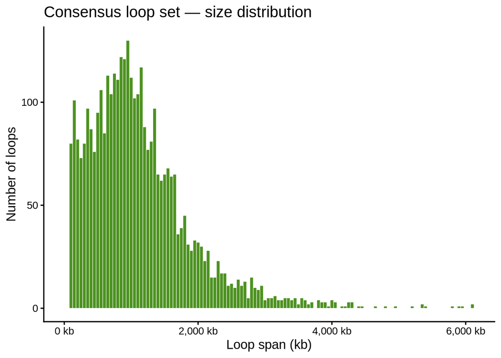

```r
ggplot(loops_consensus, aes(x = loop_size_kb)) +
  geom_histogram(
    binwidth = 50, fill = "#4D9221", colour = "white",
    linewidth = 0.2
  ) +
  scale_x_continuous(
    labels = comma_format(suffix = " kb"),
    limits = c(0, NA)
  ) +
  labs(
    x     = "Loop span (kb)",
    y     = "Number of loops",
    title = "Consensus loop set — size distribution"
  ) +
  theme_classic(base_size = 13)
```

Most loops are below 2000kb size.

## 3. Differential Loop Analysis

Following the paper, we quantify raw Hi-C contact counts at 40 kb resolution of each called loop, then apply DESeq2 to test for differential analysis.

### 3.1 Prepare 40 kb Coolers

The individual replicate files contain 10 kb bins. We coarsen by a factor of 4 to reach 40 kb using `cooler coarsen`.

```bash
for SAMPLE in mock_HiC_rep1 mock_HiC_rep2 cov_HiC_rep1 cov_HiC_rep2; do
    cooler coarsen \
        --nproc 4 \
        -k 4 \
        ./GSE179184_RAW/${SAMPLE}.mcool::/resolutions/10000 \
        -o ./out/${SAMPLE}_40kb.cool
    echo "Coarsened: ${SAMPLE}_40kb.cool"
done
```

[output not shown]

[output cut: 20 more lines]

[output not shown]

### 3.2 Extract Raw Contact Counts at Each Loop Locus

```python
import cooler
import numpy as np
import pandas as pd

RESOLUTION = 40_000

SAMPLES = {
    "mock_rep1": "./GSE179184_RAW/mock_HiC_rep1.mcool::/resolutions/10000",
    "mock_rep2": "./GSE179184_RAW/mock_HiC_rep2.mcool::/resolutions/10000",
    "cov_rep1":  "./GSE179184_RAW/cov_HiC_rep1.mcool::/resolutions/10000",
    "cov_rep2":  "./GSE179184_RAW/cov_HiC_rep2.mcool::/resolutions/10000",
}

clrs = {name: cooler.Cooler(path) for name, path in SAMPLES.items()}

loops = pd.read_csv(
    "./out/loops_consensus_chr14.bedpe",
    sep="\t",
    header=None,
    names=["chrom1", "start1", "end1", "chrom2", "start2", "end2", "loop_id"],
)

loops = loops.drop(0)
loops[["start1", "end1", "start2", "end2"]] = loops[["start1", "end1", "start2", "end2"]].astype(int)

rows = []
for _, lp in loops.iterrows():
    m1 = int(((lp.start1 + lp.end1) // 2) // RESOLUTION * RESOLUTION)
    m2 = int(((lp.start2 + lp.end2) // 2) // RESOLUTION * RESOLUTION)

    row = {"loop_id": lp.loop_id}
    for name, clr in clrs.items():
        try:
            pixel = clr.matrix(balance=False).fetch(
                (lp.chrom1, m1, m1 + RESOLUTION),
                (lp.chrom2, m2, m2 + RESOLUTION),
            )
            row[name] = int(np.nansum(pixel))
        except Exception:
            row[name] = 0
    rows.append(row)

count_df = pd.DataFrame(rows)
count_df.to_csv("./out/loop_raw_counts_40kb.tsv", sep="\t", index=False)
print(f"Saved count matrix: {count_df.shape[0]} loops at 10kb resolution")
```

```
## Saved count matrix: 3580 loops at 10kb resolution
```

### 3.3 DESeq2 Differential Loop Testing

Here we perform DESeq2 differential analysis on the raw HI-C contact counts at 40kb resolution.

```r
counts_raw <- read_tsv("./out/loop_raw_counts_40kb.tsv", show_col_types = FALSE)

count_mat <- counts_raw %>%
  select(mock_rep1, mock_rep2, cov_rep1, cov_rep2) %>%
  as.matrix()
rownames(count_mat) <- counts_raw$loop_id

keep <- rowSums(count_mat) > 0
count_mat <- count_mat[keep, , drop = FALSE]
cat(sprintf(
  "Loops retained after count filtering: %d / %d\n",
  sum(keep), length(keep)
))
```

```
## Loops retained after count filtering: 3580 / 3580
```

```r
col_data <- data.frame(
  condition = factor(c("Mock", "Mock", "SARS_CoV_2", "SARS_CoV_2"),
    levels = c("Mock", "SARS_CoV_2")
  ),
  row.names = c("mock_rep1", "mock_rep2", "cov_rep1", "cov_rep2")
)

dds <- DESeqDataSetFromMatrix(
  countData = count_mat,
  colData   = col_data,
  design    = ~condition
)
dds <- DESeq(dds, quiet = TRUE)

res <- results(
  dds,
  contrast = c("condition", "SARS_CoV_2", "Mock"),
  alpha = 0.1,
  pAdjustMethod = "BH",
  independentFiltering = FALSE
)

summary(res)
```

```
##
## out of 3580 with nonzero total read count
## adjusted p-value < 0.1
## LFC > 0 (up)       : 30, 0.84%
## LFC < 0 (down)     : 119, 3.3%
## outliers [1]       : 0, 0%
## low counts [2]     : 0, 0%
## (mean count < 0)
## [1] see 'cooksCutoff' argument of ?results
## [2] see 'independentFiltering' argument of ?results
```

```r
res_df <- as.data.frame(res) %>%
  rownames_to_column("loop_id") %>%
  left_join(
    loops_consensus %>% select(loop_id, loop_size_kb),
    by = "loop_id"
  ) %>%
  mutate(
    direction = case_when(
      !is.na(padj) & padj < 0.1 & log2FoldChange > 0 ~ "Strengthened",
      !is.na(padj) & padj < 0.1 & log2FoldChange < 0 ~ "Weakened",
      TRUE ~ "NS"
    ),
    direction = factor(direction, levels = c("Weakened", "NS", "Strengthened"))
  )

n_weak <- sum(res_df$direction == "Weakened")
n_strong <- sum(res_df$direction == "Strengthened")
n_total <- nrow(res_df)

cat(sprintf(
  "Weakened loops:     %d  (%.1f%%)\n",
  n_weak, 100 * n_weak / n_total
))
```

```
## Weakened loops:     119  (3.3%)
```

```r
cat(sprintf(
  "Strengthened loops: %d  (%.1f%%)\n",
  n_strong, 100 * n_strong / n_total
))
```

```
## Strengthened loops: 30  (0.8%)
```

```r
cat(sprintf(
  "Not significant:    %d  (%.1f%%)\n",
  n_total - n_weak - n_strong,
  100 * (n_total - n_weak - n_strong) / n_total
))
```

```
## Not significant:    3431  (95.8%)
```

The paper reported that genome wide 2.96% of loops were weakened and 4.7% were strengthened. We find that on chromosome 14, 3.3% are weakened and 0.8% are strengthened. This does not reflect the findings of the paper, but may be an artifact of looking solely at chromosome 14.

## 4. Visualisations

### 4.1 Volcano Plot

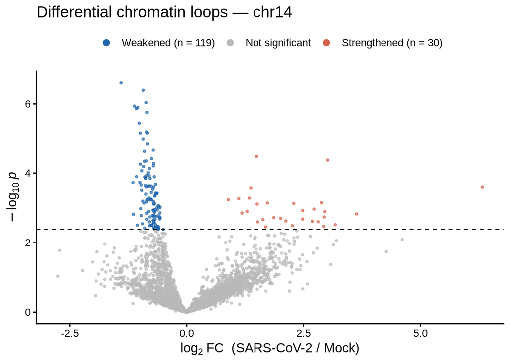

```r
p_cutoff <- res_df %>%
  filter(!is.na(padj), padj < 0.1) %>%
  pull(pvalue) %>%
  max(na.rm = TRUE)

col_map <- c(
  Weakened = "#2166AC",
  NS = "grey72",
  Strengthened = "#D6604D"
)

label_map <- c(
  Weakened     = sprintf("Weakened (n = %d)", n_weak),
  NS           = "Not significant",
  Strengthened = sprintf("Strengthened (n = %d)", n_strong)
)

res_df %>%
  filter(!is.na(pvalue)) %>%
  arrange(direction) %>%
  ggplot(aes(
    x = log2FoldChange,
    y = -log10(pvalue),
    colour = direction
  )) +
  geom_point(size = 0.8, alpha = 0.65) +
  geom_hline(
    yintercept = -log10(p_cutoff),
    linetype = "dashed", colour = "black", linewidth = 0.45
  ) +
  scale_colour_manual(values = col_map, labels = label_map) +
  labs(
    x      = expression(log[2] ~ "FC  (SARS-CoV-2 / Mock)"),
    y      = expression(-log[10] ~ italic(p)),
    colour = NULL,
    title  = "Differential chromatin loops — chr14"
  ) +
  guides(colour = guide_legend(override.aes = list(size = 2.5, alpha = 1))) +
  theme_classic(base_size = 13) +
  theme(legend.position = "top")
```

The observed fold-changes across both weakened and strengthened loops are comparable to the changes reported in the paper (extended data figure 8). However, the ratio of strengthened to weakened loops varies wildly between this analysis and the papers findings as previously noted.

### 4.2 Loop-Size Distribution for Differential Loops

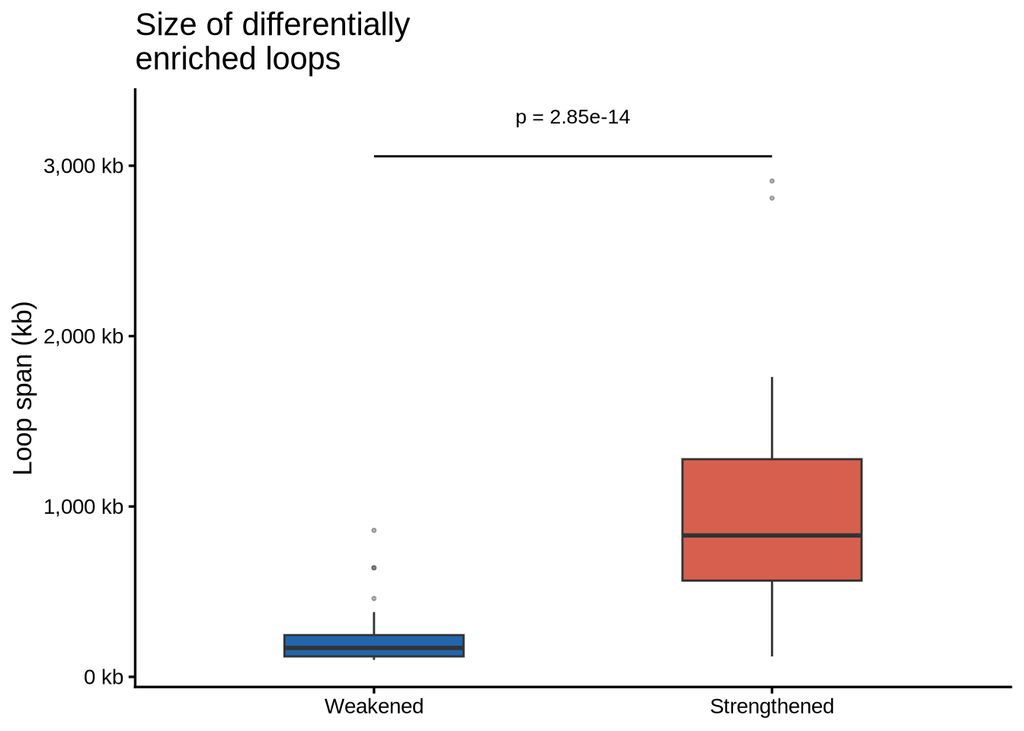

```r
diff_loops <- res_df %>%
  filter(direction != "NS", !is.na(loop_size_kb)) %>%
  droplevels()

wt <- wilcox.test(
  loop_size_kb ~ direction,
  data  = diff_loops,
  exact = FALSE
)

y_bar <- max(diff_loops$loop_size_kb, na.rm = TRUE)

ggplot(diff_loops, aes(x = direction, y = loop_size_kb, fill = direction)) +
  geom_boxplot(
    outlier.size = 0.6, outlier.alpha = 0.35,
    width = 0.45, linewidth = 0.5
  ) +
  annotate("segment",
    x = 1, xend = 2,
    y = y_bar * 1.05, yend = y_bar * 1.05,
    colour = "black", linewidth = 0.5
  ) +
  annotate("text",
    x = 1.5, y = y_bar * 1.13, hjust = 0.5, size = 3.5,
    label = sprintf("p = %.2e", wt$p.value)
  ) +
  scale_fill_manual(
    values = c(Weakened = "#2166AC", Strengthened = "#D6604D"),
    guide  = "none"
  ) +
  scale_y_continuous(labels = comma_format(suffix = " kb")) +
  labs(
    x     = NULL,
    y     = "Loop span (kb)",
    title = "Size of differentially\nenriched loops"
  ) +
  theme_classic(base_size = 13)
```

The paper reports that virus-weakened loops are predominantly short, while strengthened loops are long and the range of different lengths is larger in strengthened loops. This is consistent with our analysis of chromosome 14.

## 5. Aggregate Peak Analysis (APA)

We perform aggregate peak analysis on all conditions and loop change types using `coolpuppy`.

### 5.1 Export Differential Loop Subsets

```r
write_bedpe <- function(ids, file) {
  loops_consensus %>%
    filter(loop_id %in% ids) %>%
    select(chrom1, start1, end1, chrom2, start2, end2, loop_id) %>%
    write_tsv(file, col_names = TRUE)
  cat(sprintf("Wrote %d loops to %s\n", length(ids), file))
}

write_bedpe(
  filter(res_df, direction == "Weakened") %>% pull(loop_id),
  "./out/loops_weakened.bedpe"
)
```

```
## Wrote 119 loops to ./out/loops_weakened.bedpe
```

```r
write_bedpe(
  filter(res_df, direction == "Strengthened") %>% pull(loop_id),
  "./out/loops_strengthened.bedpe"
)
```

```
## Wrote 30 loops to ./out/loops_strengthened.bedpe
```

### 5.2 Run coolpuppy

```bash
# consensus loops
coolpup.py \
    --expected ./out/expected_mock_10kb.tsv \
    --view ./out/chr14_view.tsv \
    --flank 100000 \
    ./out/merged_mock_HiC_multi.mcool::/resolutions/10000 \
    ./out/loops_consensus_chr14.bedpe \
    --outname ./out/apa_mock_all.clpy

coolpup.py \
    --expected ./out/expected_cov_10kb.tsv \
    --view ./out/chr14_view.tsv \
    --flank 100000 \
    ./out/merged_cov_HiC_multi.mcool::/resolutions/10000 \
    ./out/loops_consensus_chr14.bedpe \
    --outname ./out/apa_cov_all.clpy

# weakened
coolpup.py \
    --expected ./out/expected_mock_10kb.tsv \
    --view ./out/chr14_view.tsv \
    --flank 100000 \
    ./out/merged_mock_HiC_multi.mcool::/resolutions/10000 \
    ./out/loops_weakened.bedpe \
    --outname ./out/apa_mock_weakened.clpy

coolpup.py \
    --expected ./out/expected_cov_10kb.tsv \
    --view ./out/chr14_view.tsv \
    --flank 100000 \
    ./out/merged_cov_HiC_multi.mcool::/resolutions/10000 \
    ./out/loops_weakened.bedpe \
    --outname ./out/apa_cov_weakened.clpy

# strengthened
coolpup.py \
    --expected ./out/expected_mock_10kb.tsv \
    --view ./out/chr14_view.tsv \
    --flank 100000 \
    ./out/merged_mock_HiC_multi.mcool::/resolutions/10000 \
    ./out/loops_strengthened.bedpe \
    --outname ./out/apa_mock_strengthened.clpy

coolpup.py \
    --expected ./out/expected_cov_10kb.tsv \
    --view ./out/chr14_view.tsv \
    --flank 100000 \
    ./out/merged_cov_HiC_multi.mcool::/resolutions/10000 \
    ./out/loops_strengthened.bedpe \
    --outname ./out/apa_cov_strengthened.clpy
```

### 5.3 Visualise APA Heatmaps

```python
import numpy as np
import matplotlib.pyplot as plt
import pandas as pd
import re
import h5sparse
import os
from matplotlib.colors import LogNorm

def load_pileup_df(filename, quaich=False, skipstripes=False):
    """
    Loads a dataframe saved using `save_pileup_df`

    Parameters
    ----------
    filename : str
        File to load from.
    quaich : bool, optional
        Whether to assume standard quaich file naming to extract sample name and bedname.
        The default is False.

    Returns
    -------
    annotation : pd.DataFrame
        Pileups are in the "data" column, all metadata in other columns

    """
    with h5sparse.File(filename, "r", libver="latest") as f:
        metadata = dict(zip(f["attrs"].attrs.keys(), f["attrs"].attrs.values()))
        dstore = f["data"]
        data = []
        for chunk in dstore.iter_chunks():
            chunk = dstore[chunk]
            data.append(chunk)
        annotation = pd.read_hdf(filename, "annotation")
        annotation["data"] = data
        vertical_stripe = []
        horizontal_stripe = []
        coordinates = []
        if not skipstripes:
            try:
                for i in range(len(data)):
                    vstripe = "vertical_stripe_" + str(i)
                    hstripe = "horizontal_stripe_" + str(i)
                    coords = "coordinates_" + str(i)
                    vertical_stripe.append(f[vstripe][:].toarray())
                    horizontal_stripe.append(f[hstripe][:].toarray())
                    coordinates.append(f[coords][:].astype("U13"))
                annotation["vertical_stripe"] = vertical_stripe
                annotation["horizontal_stripe"] = horizontal_stripe
                annotation["coordinates"] = coordinates
            except KeyError:
                pass
    for key, val in metadata.items():
        if key != "version":
            annotation[key] = val
    if quaich:
        basename = os.path.basename(filename)
        sample, bedname = re.search(
            "^(.*)-(?:[0-9]+)_over_(.*)_(?:[0-9]+-shifts|expected).*\.clpy", basename
        ).groups()
        annotation["sample"] = sample
        annotation["bedname"] = bedname
    return annotation

def load_pileup(path):
    df = load_pileup_df(path)
    return np.nanmean(np.stack(df["data"].values), axis=0)

def plot_apa_pair(path_mock, path_cov, title_mock, title_cov):
    mat_mock = load_pileup(path_mock)
    mat_cov = load_pileup(path_cov)

    bin_size_kb = (2 * 100_000) / (mat_mock.shape[0] - 1) / 1000

    combined = np.concatenate([mat_mock.flatten(), mat_cov.flatten()])
    valid_vals = combined[(~np.isnan(combined)) & (combined > 0)]
    vmin = np.nanpercentile(valid_vals, 5)
    vmax = np.nanpercentile(valid_vals, 95)

    fig, axes = plt.subplots(1, 2, figsize=(9, 4.5))

    n = mat_mock.shape[0]
    centre = n // 2
    flank_kb = centre * bin_size_kb
    extent = [-flank_kb, flank_kb, flank_kb, -flank_kb]

    for ax, mat, title in zip(axes, [mat_mock, mat_cov], [title_mock, title_cov]):
        im = ax.matshow(mat, cmap="YlOrRd", norm=LogNorm(vmin=vmin, vmax=vmax), extent=extent)

        ax.set_title(title, fontsize=11, pad=12, fontweight="bold")
        ax.set_xlabel("Distance from center (kb)", fontsize=9)
        ax.xaxis.set_label_position('bottom')
        ax.xaxis.tick_bottom()

        ax.set_xticks([-flank_kb, 0, flank_kb])
        ax.set_yticks([-flank_kb, 0, flank_kb])

    fig.subplots_adjust(left=0.08, right=0.82, bottom=0.15, top=0.85, wspace=0.35)

    cbar_ax = fig.add_axes([0.86, 0.22, 0.025, 0.55])
    cbar = fig.colorbar(im, cax=cbar_ax)
    cbar.set_label("Enrichment (O/E)", fontsize=10, labelpad=8)

    return fig
```

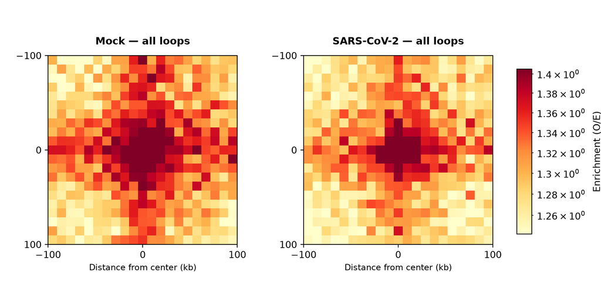

```python
plot_apa_pair(
    "./out/apa_mock_all.clpy", "./out/apa_cov_all.clpy",
    "Mock — all loops", "SARS-CoV-2 — all loops",
)
plt.show()
```

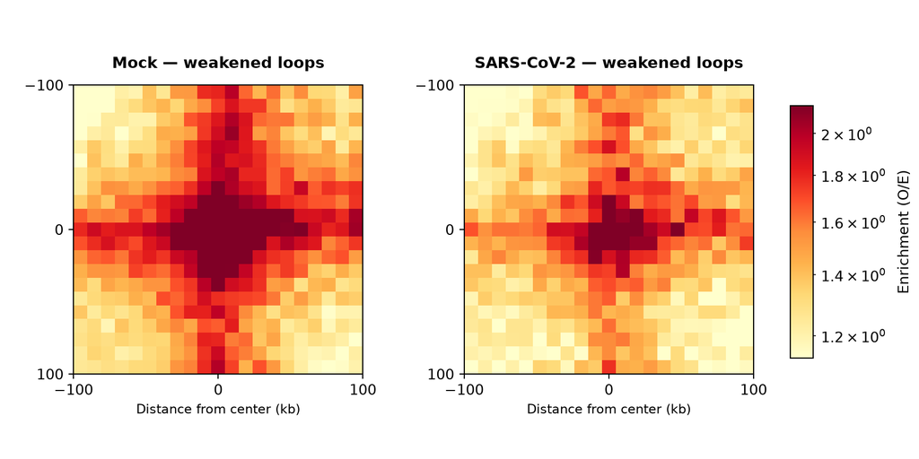

```python
plot_apa_pair(
    "./out/apa_mock_weakened.clpy", "./out/apa_cov_weakened.clpy",
    "Mock — weakened loops", "SARS-CoV-2 — weakened loops",
)
plt.show()
```

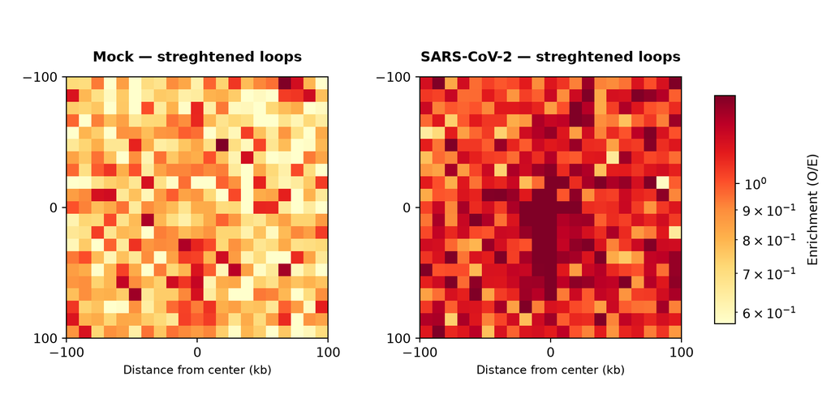

```python
plot_apa_pair(
    "./out/apa_mock_strengthened.clpy", "./out/apa_cov_strengthened.clpy",
    "Mock — streghtened loops", "SARS-CoV-2 — streghtened loops",
)
plt.show()
```

The enrichment score of all loops in mock and infected groups is comparable. Loops of the weakened category have a lower enrichment score in the infected group than in the mock group. These result match the observations in the paper.

## Discussion of our results

Since our analysis was constrianed to chromosome 14 and to the analysis of loops at 10 kb resolution, the sample size of loops for our analysis was lower than in the paper. Our results do not directly replicate the results in the paper, in paricular we did not find that more loops were strenghtened than weakened, instead findign the reverse. However the reported fold changes, as well as length distributions for strengthened and weakened loops aligned with out findings. Our APA analysis also mostly supports the findings in the paper.

In conclusion we were able to show that some loops are weakened or strengthened in the infected group, but could not replicate the exact quantitåtive findings of the paper we tried to reproduce. This can in large parts be explained by our analysis focusing only on a subset of the experimental data.